# branching_locally

# Branching with local git

## A scenario

Imagine you are running a coffee roaster. You have code that produces a daily report that is emailed to your team. Each day the point of sale system saves a datafile in your repository (`data_monday.csv.`). Each night your computer executes a script to create and email the report (report_script.Rmd).

Currently the report is pretty simple, it’s a a table of sales divided up between in-store and online. Each day’s sales are added as a new row in the table.

```bash
mkdir scratch_branching
cd scratch_branching
git init
```

```
Initialized empty Git repository in scratch_branching/.git/
```

We can now add the reporting script and the data for monday. To simulate editing a file using an editor we can use some fancy syntax so you can copy and paste it.

```bash
cat >> reporting_script.Rmd <<< "# Initial code for table report"
git add reporting_script.Rmd
git commit -m "starting setup"
```

[output not shown]

Depending on the default setting for your git you may want to rename `master` to `main`

```bash
git branch -m master main
```

The scripts runs normally on Monday night.

One Tuesday morning you decide that the data would be better presented as a chart. You have some ideas but rightly decide it will take more than a day or two to get that working. In the meantime you still have to produce the report. So you create a branch called `towards_chart` and begin working there, leaving the main branch untouched to produce the Tuesday night report.

```bash
git branch towards_chart
git checkout towards_chart
```

Again we can simulate editing the file.

```bash
cat >> reporting_script.Rmd <<< "# Work towards charts"
git status
```

```
On branch towards_chart
Changes not staged for commit:
  (use "git add <file>..." to update what will be committed)
  (use "git restore <file>..." to discard changes in working directory)
    modified:   reporting_script.Rmd

no changes added to commit (use "git add" and/or "git commit -a")
```

```bash
git add reporting_script.Rmd
git commit -m "Worked towards charts"
```

```
[towards_chart acc3f42] Worked towards charts
 1 file changed, 1 insertion(+)
```

On Tuesday you see that the report ran fine (using the code in `main`) and you continue to work on the charts.

```bash
cat >> reporting_script.Rmd <<< "# More work towards charts"
git add reporting_script.Rmd
git commit -m "More work towards charts"
```

[output not shown]

On Wednesday morning, though, you get an error from your reporting script. The online sales system updated and the data files now include a new column saying whether a sale was cash or credit. You know how to get things working again, but you still aren’t ready to launch your chart system. You don’t want to wait until your chart work is finished to get the report going again.

So you switch to main, edit the reporting file to handle the new column, then add and commit the change.

```bash
git checkout main
```

```
Switched to branch 'main'
```

Now we are back on the `main` branch and we won’t see our work towards the charts at all. So over on the `towards_chart` branch we can work away without upsetting the working code on `main`.

```bash
cat reporting_script.Rmd
```

[output not shown]

So now we can, without involving our work towards the chart, make the bugfix on `main`.

```bash
cat >> reporting_script.Rmd <<< "# Fix to match new data format"
git add reporting_script.Rmd
git commit -m "A fix to match new data format"
```

Happily the report runs fine on Wednesday night.

Thursday morning you switch back to the `towards_chart` branch and are pleased to get things working.

```bash
git checkout towards_chart
cat >> reporting_script.Rmd <<< "# Code to finalize the charts"
git add reporting_script.Rmd
git commit -m "Finished up the charts"
```

You are ready to add the chart into the report by moving the code to the `main` branch.

But if you just merge the code back to `main` you may find that the code for the chart doesn’t work with the change to handle the updated data files. So you may have some merging to do. But you don’t know if you can get that done before the report has to run, and you don’t want to get caught fiddling with `main` because if the report tries to run you could end up with nothing going out that night.

So you first merge `main` over to your `towards_chart` branch, and ensure that things work well and the two pieces of work done in parallel work well together (charts and dealing with the new column).

First confirm which branch you are in, this command lists the branches and the one highlighted with the * is the current branch. `git status` can also show you.

```bash
git branch -v
```

```
git branch -v
  main          576bc90 A fix to match new data format
* towards_chart bef7b72 Finished up the charts
```

Then merge over the `main` branch into the `towards_chart` branch.

```bash
git merge main
```

```
Auto-merging reporting_script.Rmd
CONFLICT (content): Merge conflict in reporting_script.Rmd
Automatic merge failed; fix conflicts and then commit the result.
```

Ah, good thing we did this on the branch because we do end up with a conflict. Git can resolve some conflicts but not all. Git shows conflicts by adding special lines of text into the file (using `>>>>>>` and `<<<<<` as indicators. To resolve them we remove those lines and leve the file the way we want it to be.

```
# Initial code for table report
<<<<<<< HEAD
# Work towards charts
# More work towards charts
# Code to finalize the charts
=======
# Fix to match new data format
>>>>>>> main
```

The parts separated by `========` show edits that conflict. Looking at this we can see that we want all the lines, so we edit the file to show:

```
# Initial code for table report
# Fix to match new data format
# Work towards charts
# More work towards charts
# Code to finalize the charts
```

Now we can save that file. Git knows that we are fixing a conflict, so `git status` shows:

```
On branch towards_chart
You have unmerged paths.
  (fix conflicts and run "git commit")
  (use "git merge --abort" to abort the merge)

Unmerged paths:
  (use "git add <file>..." to mark resolution)
    both modified:   reporting_script.Rmd

no changes added to commit (use "git add" and/or "git commit -a")
```

And now we can `add` and `commit` to finish the merge.

```bash
git add reporting_script.Rmd
git commit -m "merged bug fix with charts code"
```

```
[towards_chart e420a05] merged bug fix with charts code
```

(Git can only flag syntactical conflicts, not semantic conflicts, so one would also try running some test reports to make sure things are all working).

So once you’ve resolved all issues, then you can merge the `towards_chart` branch back to `main`, signalling that you are ready to launch your new report with charts.

```bash
git checkout main
git merge towards_chart
```

```
Switched to branch 'main'
Updating 576bc90..e420a05
Fast-forward
 reporting_script.Rmd | 3 +++
 1 file changed, 3 insertions(+)
```

```bash
git log --oneline --abbrev-commit --all --graph --decorate --color
```

Which will show us this (using an image here because the color doesn’t copy):

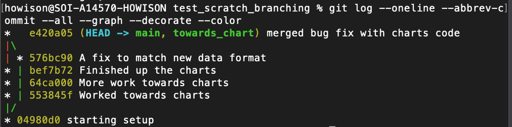